# The Values of Pitching and Fielding for Preventing Runs in Baseball

David Schmerfeld

December 2020

## Abstract

In Major League Baseball, pitching and fielding both contribute to preventing runs on defense. A linear regression model using a standardized average of Defensive Runs Saved (DRS), Ultimate Zone Rating (UZR), Fielding Runs Above Average (FRAA), and Outs Above Average (OAA) shows that fielding contributes 11% to defense. Best subset selection, a linear regression with lasso shrinkage, and a random forests model with a variable importance plot indicate that DRS is the best overall advanced fielding statistic for measuring fielding in terms of preventing runs. Nevertheless, coefficients in linear regression models suggest that all of the advanced fielding metrics overestimate the extent to which fielding contributes to preventing runs. Confidence intervals (95%) for the coefficients in the linear regression model were determined by bootstrapping and indicate that improving fielding from the lower to upper quartile as measured by the standardized average fielding metric will result in 3.7–4.5 more wins. Meanwhile, obtaining 1.4–2.0 extra strikeouts per year is equivalent to an additional run saved by fielding as measured by the standardized average fielding metric.

## Introduction

In Major League Baseball, the number of games teams win can be estimated by the number of runs teams score and the number of runs teams give up. Teams that score more runs on offense should win more games. Likewise, teams that give up less runs on defense should also win more games (Winston, 2012/2009, pp. 3–5). Generally, 10 extra runs scored or 10 less runs given up over the course of a season will translate to an additional win (Winston, 2012/2009, p. 68).

On offense, an average home run provides 2 more runs than an out. This number is more than 1 because sometimes runners will be on base, which allows a home run to produce more than 1 run. Likewise, a walk is worth 0.7 more runs than an out (“wOBA & FIP Constants”, n.d.). This number is less than 1 because sometimes the player who walked will not eventually score. The cost of allowing an average hit is around 0.8 runs (Winston, 2012/2009, p. 68).

Pitching and fielding together comprise defense. It is difficult to measure the extent of the defensive contribution of the pitcher relative to the fielders (Baumer & Zimbalist, 2014, p. 58). As a result, historically there has been no consensus as to “exactly which part of defense was pitching and which fielding, and so no one could say exactly how important fielding was” (Lewis, 2004/2003, p. 98).

Statistics considered generally to be the pitcher’s entire responsibility are walks, strikeouts, and home runs allowed. Walks, strikeouts, and for the most part, home runs, do not involve any participation by fielders. For batted balls hit in play, it is difficult to separate pitching, fielding, and other factors, to quantify how much each is responsible for the result (McCracken, 2001).

Pitchers’ strikeout rates and walk rates do not change much from one season to the next. The batting average of balls hit in play does, however, vary substantially from one season to the next (Baumer & Zimbalist, 2014, pp. 59–62). As a result, the number of earned runs a pitcher will give up in the future is more accurately predicted when only considering the pitcher’s past strikeouts, walks, and home runs allowed (as opposed to considering the past number of earned runs the pitcher allowed) (Winston, 2012/2009, p. 49).

The overall impact of fielding performance is less understood than pitching performance. Early research concluded that because 12% of runs are unearned and defense is half of baseball, fielding only accounts for 6% of baseball with pitching being 44% (Thorn & Palmer, 2015/1984, p. 178). One argument is that fielding is overvalued because “[t]he variance between the best and worst fielders on the outcome of a game is a lot smaller than the variance between the best hitters and the worst hitters” (Lewis, 2004/2003, p. 137). Fielding ratings indicate that most starting fielders do not cost or save their team 2 or more wins per year (Winston, 2012/2009, p. 68).

Other evidence suggests that fielding has become undervalued. For example, Tampa Bay went from last place in 2007 to first place in 2008, winning 29 more games, when their fielding also improved from last place to first place. Meanwhile, in 2008, Tampa Bay actually scored less runs on offense than in 2007, while their strikeouts, walks, and home runs allowed were the same or similar in 2007 and 2008 (Baumer & Zimbalist, 2014, pp. 71–72).

An accurate valuation of fielding would allow for more efficient spending. In free agency, teams spend about $8 million for each additional win (Edwards, 2020). Knowing how much fielding contributes to preventing runs would allow an efficient allocation of spending between pitching and fielding.

Part of the problem in valuing fielding is accurately measuring it in the first place. Traditionally, the only measure of fielding effectiveness was fielding percentage. Fielding percentage measures the percentage of plays a fielder makes without an error. However, problems with fielding percentage are that scoring errors is subjective and fielding percentage does not count batted balls that a player does not get to. A player cannot make an error on a ball he does not get to. Therefore, an immobile player who does not field many balls (and only fields easy balls) could have a high fielding percentage, but his immobility would be a detriment to preventing hits and runs (Winston, 2012/2009, pp. 64–66).

More advanced fielding statistics have been developed in an effort to improve upon fielding percentage. Four of the more popular measures are Ultimate Zone Rating (UZR) (Slowinski, 2010), Defensive Runs Saved (DRS) (Reiff, 2020), Fielding Runs Above Average (FRAA) (“FRAA”, n.d.), and Outs Above Average (OAA) (“Outs Above Average (OAA)”, n.d.). There is no consensus as to which of these advanced fielding statistics is best at measuring fielding, although research has compared their predictive accuracy (Judge & O’Rourke, 2020).

There are two objectives to this paper. The first is to determine the amount by which fielding contributes to preventing runs compared to pitching. The second is to evaluate which fielding metrics best describe the fielders’ abilities to prevent runs.

The data set used to answer these questions includes the following variables for each team and season from 2003–2019, and was obtained from [baseball-reference.com](http://www.baseball-reference.com/leagues/MLB/2019-batting-pitching.shtml):

- Total Runs Allowed (`R`);
- Home Runs Allowed (`HR`);
- Base-on-Balls (Walks) (`BB`);
- Strikeouts (`SO`); and
- Hit-by-Pitch (`HBP`).

These statistics represent the response variable (Total Runs Allowed `R`) and the predictor variables corresponding to the pitching aspect of defense. The Base-on-Balls `BB` and Hit-by-Pitch `HBP` statistics were combined into a single value, `BB_HBP` (i.e., `BB_HBP` = `BB` + `HBP`).

A summary of the pitching predictor variables is as follows:

| Statistic | Minimum | Lower Quartile | Median | Upper Quartile | Maximum |
| --- | --- | --- | --- | --- | --- |
| `HR` | 96 | 152 | 170 | 190 | 305 |
| `SO` | 764 | 1,062 | 1,174 | 1,286 | 1,687 |
| `BB_HBP` | 391 | 527 | 570 | 616 | 768 |

Also, the following fielding statistics were obtained from [fangraphs.com](http://www.fangraphs.com/leaders.aspx?pos=all&stats=fld&lg=all&qual=0&type=1&season=2020&month=0&season1=2020&ind=0&team=0,ts&rost=0&age=0&filter=&players=0&startdate=&enddate=) and added to the dataset:

- Fielding Percentage (`FP`)
- Ultimate Zone Rating (`UZR`)
- Defensive Runs Saved (`DRS`).

The other fielding statistics are Fielding Runs Above Average (`FRAA`) and Outs Above Average (`OAA`), which were obtained from [baseballprospectus.com](http://legacy.baseballprospectus.com/sortable) and [baseballsavant.com](http://baseballsavant.mlb.com/leaderboard/outs_above_average?type=Fielding_Team&year=2019&team=&range=year&min=q&pos=&roles=&viz=show), respectively.

A new variable, `Avg_Fld` was also created, which is the average of the standardized versions of each of the advanced fielding statistics (`UZR`, `DRS`, `FRAA`, and `OAA`).

After averaging the standardized values, `Avg_Fld` was rescaled to have a mean of 0 and the same standard deviation as Total Runs Allowed. `Avg_Fld` was rescaled in this way to represent the runs above or below average that a team defense saves to aid in interpretability.

A summary of the `Avg_Fld` statistic is:

| Minimum | Lower Quartile | Median | Upper Quartile | Maximum |
| --- | --- | --- | --- | --- |
| -303 | -56 | 3 | 64 | 224 |

The final data set includes the following variables:

| Abbreviation | Statistic |
| --- | --- |
| `R` | Total Runs Allowed |
| `HR` | Home Runs Allowed |
| `SO` | Strikeouts |
| `BB_HBP` | Base-on-Balls + Hit-by-Pitch |
| `FP` | Fielding Percentage |
| `UZR` | Ultimate Zone Rating |
| `DRS` | Defensive Runs Saved |
| `FRAA` | Fielding Runs Above Average |
| `OAA` | Outs Above Average |
| `Avg_Fld` | Average of Standardized `UZR`, `DRS`, `FRAA`, and `OAA` |

The `OAA` statistic has only been available since 2017. Therefore, two separate data sets were prepared. One data set includes team-by-team data from each of the 2003–2019 seasons, but does not include the `OAA` variable. There are 30 teams that provide 510 total observations in this first data set.

The second data set contains three seasons of data from 2017–2019 (90 total data points) and includes the `OAA` variable.

A scatterplot of all of the variables is shown below:

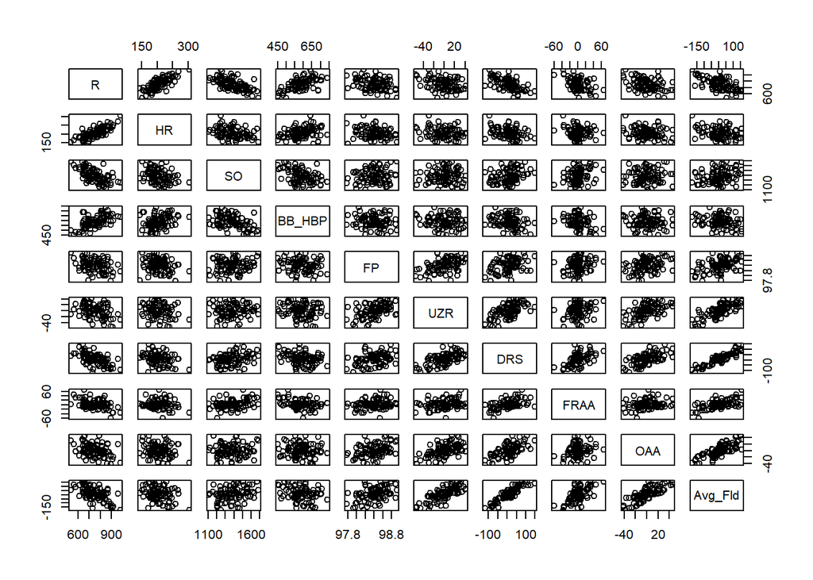

The strongest linear relationship is between `R` and `HR`. As home runs allowed increase, runs allowed also increase. There are also linear relationships between `R` and `SO`, and `R` and `BB_HBP`. As strikeouts increase, runs allowed decrease. As walks and hit-by-pitches increase, runs allowed increase.

There is also a relationship between runs allowed and each of the defensive metrics, although not as strong. Generally, as fielding improves, runs allowed decrease.

Some of the fielding metrics are more correlated than others. That is, `DRS` is correlated with `UZR` and `OAA`. Also, `DRS` has the closest correlation to the `Avg_Fld` combination statistic, while `OAA` is also correlated with `Avg_Fld`.

## Methods

Both data sets will be analyzed to determine which of the predictor variables best describe the number of runs allowed each season, and the extent to which these predictors represent pitching or fielding. Three feature selection techniques will be applied: (1) linear regression with best subset selection; (2) linear regression with lasso shrinkage; and (3) random forests with variable importance plots. Then, bootstrapping will be applied to determine confidence intervals for the coefficients of the selected model.

Before applying these techniques, Variance Inflation Factors (VIFs) were computed to determine multicollinearity in the data. VIFs for each of the predictors are:

```
##        HR        SO    BB_HBP        FP       UZR       DRS      FRAA   Avg_Fld
##  1.121034  1.120423  1.244538  1.314713 16.916417 16.866348 15.408682 89.802777
```

As indicated by the VIFs, there is a very high degree of collinearity in the defensive metrics (except for `FP`). Accordingly, to reduce the VIFs to below 5, linear regression models will either include all of the defensive statistics (but not `Avg_Fld`) or `Avg_Fld` alone without the separate defensive statistics.

For the 2003–2019 data set, the VIFs without including `Avg_Fld` in the linear regression are:

```
##       HR       SO   BB_HBP       FP      UZR      DRS     FRAA
## 1.119632 1.110414 1.242808 1.310452 1.751326 2.135905 1.528704
```

For the 2017–2019 data set, the VIFs without including `Avg_Fld` in the linear regression are:

```
##       HR       SO   BB_HBP       FP      UZR      DRS     FRAA      OAA
## 1.233097 1.365604 1.293282 1.335080 1.939247 2.727566 1.455676 1.762106
```

## Results

### 1. Linear Regressions with Best Subset Selection

For the linear regression with best subset selection, the best 3-variable model for both the 2003 and 2017 seasons contained the 3 pitching-related variables: Home Runs Allowed (`HR`), Strikeouts (`SO`), and Walks plus Hit-by-Pitches (`BB_HBP`).

The best subset matrix for the 2003–2019 data set is:

```
##          HR  SO  BB_HBP FP  UZR DRS FRAA
## 1  ( 1 ) "*" " " " "    " " " " " " " "
## 2  ( 1 ) "*" "*" " "    " " " " " " " "
## 3  ( 1 ) "*" "*" "*"    " " " " " " " "
## 4  ( 1 ) "*" "*" "*"    " " "*" " " " "
## 5  ( 1 ) "*" "*" "*"    " " "*" "*" " "
## 6  ( 1 ) "*" "*" "*"    " " "*" "*" "*"
## 7  ( 1 ) "*" "*" "*"    "*" "*" "*" "*"
```

The best subset matrix for the 2017–2019 data set is:

```
##          HR  SO  BB_HBP FP  UZR DRS FRAA OAA
## 1  ( 1 ) "*" " " " "    " " " " " " " "  " "
## 2  ( 1 ) "*" "*" " "    " " " " " " " "  " "
## 3  ( 1 ) "*" "*" "*"    " " " " " " " "  " "
## 4  ( 1 ) "*" "*" "*"    " " " " "*" " "  " "
## 5  ( 1 ) "*" "*" "*"    " " " " "*" " "  "*"
## 6  ( 1 ) "*" "*" "*"    " " "*" " " "*"  "*"
## 7  ( 1 ) "*" "*" "*"    " " "*" "*" "*"  "*"
## 8  ( 1 ) "*" "*" "*"    "*" "*" "*" "*"  "*"
```

The 3-variable models had R<sup>2</sup> values of 0.752 for the 2003–2019 data and 0.8295 for the 2017–2019 data, meaning that the pitching statistics alone explained 75%–83% of the variance in runs allowed on defense.

After the 3 pitching statistics, the fielding statistic that explained the most of the remaining variance was `UZR` for 2003–2019 (R<sup>2</sup> = 0.8376) and `DRS` for 2017–2019 (R<sup>2</sup> = 0.8878). Nevertheless, the results for `UZR`, `DRS`, and `OAA` were similar. All of the individual fielding statistics explained more of the remaining variance than fielding percentage `FP`.

However, none of the individual statistics outperformed the average of all of the advanced fielding statistics, `Avg_Fld`. The pitching statistics combined with `Avg_Fld` explained 86% of the variance of runs allowed in 2003–2019, and 91% of the variance of runs allowed in 2017–2019.

In summary, the R<sup>2</sup> values for each of the linear regressions are as follows:

| Predictors | 2003–2019 | 2017–2019 |
| --- | --- | --- |
| `HR` + `SO` + `BB_HBP` + `Avg_Fld` | 0.8635 | 0.9059 |
| `HR` + `SO` + `BB_HBP` + `UZR` | 0.8376 | 0.8725 |
| `HR` + `SO` + `BB_HBP` + `DRS` | 0.8369 | 0.8878 |
| `HR` + `SO` + `BB_HBP` + `OAA` | N/A | 0.879 |
| `HR` + `SO` + `BB_HBP` + `FRAA` | 0.8037 | 0.857 |
| `HR` + `SO` + `BB_HBP` + `FP` | 0.7791 | 0.8426 |
| `HR` + `SO` + `BB_HBP` | 0.752 | 0.8295 |

Accordingly, the linear regression model that best fits the runs allowed data is:

$Runs Allowed = \beta_0 + \beta_1 HR + \beta_2 SO + \beta_3 BB\_HBP + \beta_4 Avg\_Fld$

The coefficients are:

$\beta_1$ = 1.64;  
$\beta_2$ = -0.205;  
$\beta_3$ = 0.390; and  
$\beta_4$ = -0.342.

The coefficients for the fielding predictors in each of the models using an individual advanced fielding statistic, instead of the average, `Avg_Fld`, are:

| Statistic | Coefficient (2003–2019) | Coefficient (2017–2019) |
| --- | --- | --- |
| `DRS` | -0.609 | -0.453 |
| `OAA` | N/A | -1.07 |
| `UZR` | -0.887 | -0.886 |
| `FRAA` | -0.881 | -0.832 |

### 2. Linear Regression with Lasso Shrinkage

Next, a linear regression using the lasso shrinkage method was performed.

The following plot shows the coefficients of the linear regression model for the 2017–2019 data set as a function of $log(\lambda)$.

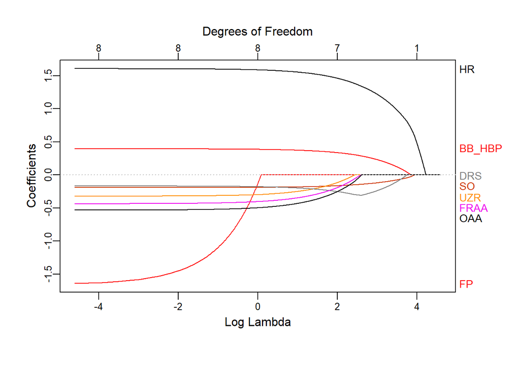

The last variables to be shrunk to 0 are `HR`, `BB_HBP`, `SO`, and `DRS`, which suggests that these are the most important predictors. By $log(\lambda)$ = 3 (i.e., $\lambda$ = 20), the coefficients for all of the other variables are 0.

Next, shrunken coefficients for the linear regression model using the `Avg_Fld` variable were determined using the lasso and 10-fold cross-validation on the 2003–2019 data set.

As the plot below shows, the mean-squared error stays about the same and does not start increasing until about $log(\lambda)$ = 2.

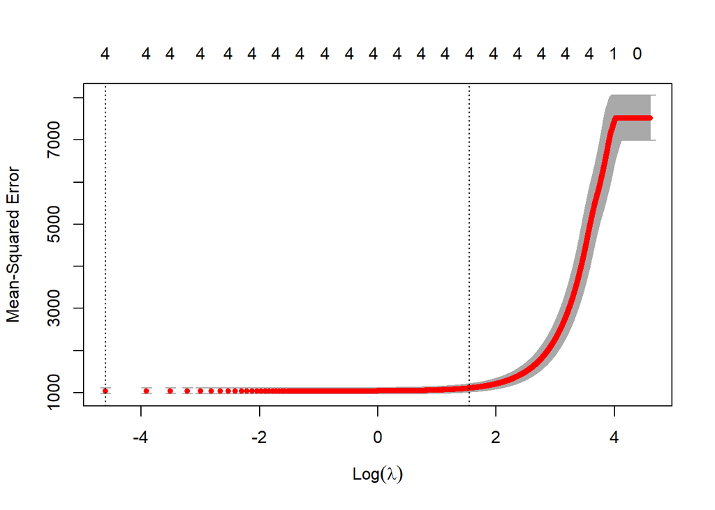

The value of $\lambda$ within 1 standard error of the minimum lambda (as shown by the dotted vertical line on the right) is 4.69.

As the graph of mean-squared error vs. $log(\lambda)$ indicates, using the $\lambda$ value of 4.69 (i.e., $log(\lambda)\approx$ 1.5), provides a mean-squared error that is practically the same as the minimum mean-squared error. It is therefore acceptable to use $\lambda$ = 4.69 for purposes of determining the shrunken coefficients.

Accordingly, the optimal linear regression model, when using the lasso to shrink the coefficients is:

$Runs Allowed = \beta_0 + \beta_1 HR + \beta_2 SO + \beta_3 BB\_HBP + \beta_4 Avg\_Fld$

The coefficients are:

$\beta_1$ = 1.50;  
$\beta_2$ = -0.178;  
$\beta_3$ = 0.360; and  
$\beta_4$ = -0.301.

### 3. Random Forests Variable Importance Plots

A random forests model was also constructed on the 2017–2019 data set. Variable importance plots were used to determine which fielding metrics perform best in the model.

The variable importance plots show the following:

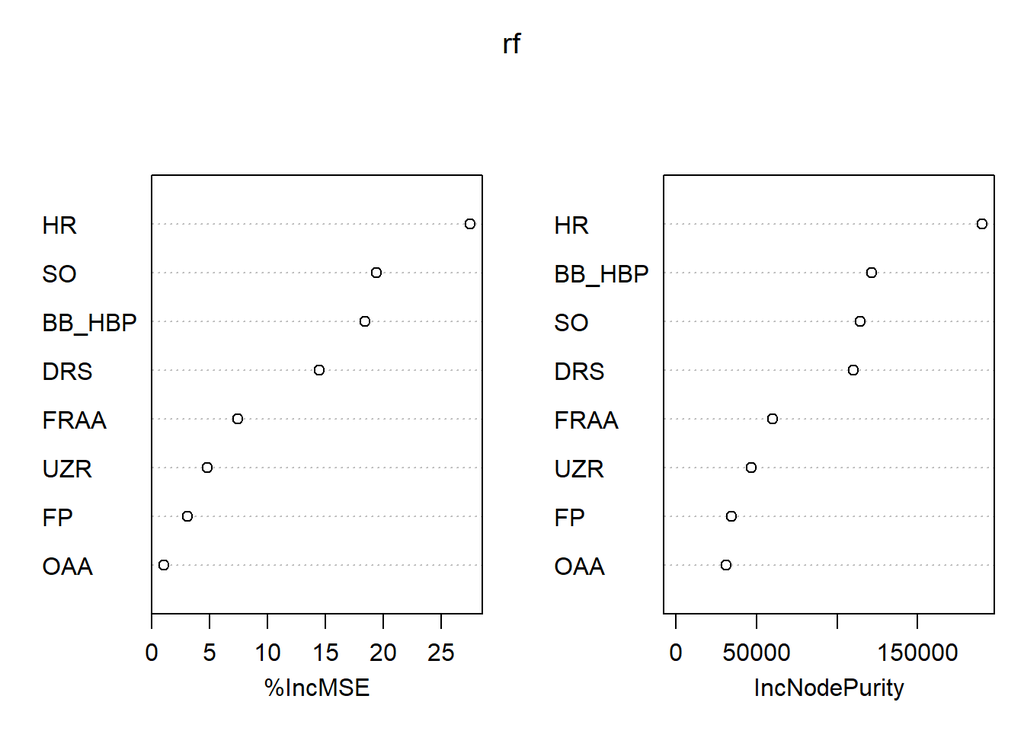

These results indicate that `HR`, `SO`, `BB_HBP`, and `DRS` are the most important variables. There is a clear separation between these 4 variables and the remaining variables.

### 4. Bootstrapping

Next, bootstrapped estimates for the coefficients in the best linear regression model were determined by randomly sampling from among the observations in the 2003–2019 data set with replacement. One thousand bootstrap estimates were used.

The bootstrap estimates provide standard errors from which 95% confidence intervals can be obtained.

The 95% confidence intervals are:

| Variable | 95% Confidence Interval |
| --- | --- |
| `HR` | 1.54, 1.74 |
| `SO` | -0.222, -0.188 |
| `BB_HBP` | 0.346, 0.433 |
| `Avg_Fld` | -0.375, -0.309 |

## Discussion

The pitching statistics alone, `HR`, `SO`, and `BB_HBP`, explain about 75.2% of the variance of runs allowed. `Avg_Fld` best described fielding, and explained 11.2% of the remaining variance, raising the R<sup>2</sup> value to 86.4%. Averaging each of the individual fielding statistics to calculate `Avg_Fld` reduces the variance when compared to each of the individual fielding statistics alone.

As defense is 50% of baseball, this results in a pitching contribution of 37.6%, and a fielding contribution of 5.6%. These numbers are very similar to the conclusion of Thorn & Palmer (2015/1984) that pitching contributes 44% to baseball, and fielding contributes 6% (p. 178). As the model only considers batted balls that are not hit in play, to the extent pitching has an effect on how well or poorly the batters hit balls that stay in play, the value of pitching would be higher. Random error will still be present, so its value would not be as high as 44%. As for fielding, although 5.6% may seem low, over the course of a 162 game season, this adds up to 9 games.

Nevertheless, the advanced fielding statistics overestimate the amount by which fielding contributes to preventing runs. That is, the coefficients for `DRS` and `UZR` in the linear regression models are -0.609 and -0.887, respectively. A one-unit change in either of these measures is designed to indicate one additional run saved or lost by the defense. However, the linear regression model for the 2003–2019 data set suggests that a one-unit change in either of these measures only changes the runs allowed by about 0.6 or about 0.9 runs.

Meanwhile, the `OAA` metric is on the scale of outs. The linear regression model for the 2017–2019 data set suggests that a one-unit change in this measure changes the runs allowed by 1.07 runs. However, obtaining one additional out would only be expected to save about 0.8 runs (Winston, 2012/2009, p. 68).

The value of a `HR` or `BB_HBP` to runs allowed on defense should correspond to the value of a `HR` or `BB_HBP` to runs scored on offense. The coefficients obtained from the lasso shrinkage provide the best correspondence to the offensive values.

To calculate the run-expectancy values of a `HR` or `BB_HBP`, the value of an out is subtracted from the run-expectancy value. Then, this result is multiplied by a constant to place it on the same scale as the on-base percentage statistic (Weinberg, 2016). On offense, the coefficient for `HR` ranged from 1.94 to 2.14 in 2003–2019. The coefficients for walks and hit-by-pitches has been about 0.7 (“wOBA & FIP Constants”, n.d.).

The shrunken lasso coefficient for `HR` is 1.50, and `SO` (i.e., an out) is -0.178. Therefore, relative to an out, the coefficient for `HR` is 1.50 + 0.178 = 1.678. The constant by which this value is multiplied for scaling purposes is typically about 1.2 (“wOBA & FIP Constants”, n.d.). Accordingly, this results in a scaled value of 2.01, which is within the range of 1.94 to 2.14.

Similarly, the shrunken lasso coefficient for `BB_HBP` is 0.360. Therefore, relative to an out, the coefficient for `BB_HBP` is 0.360 + 0.178 = 0.538. Multiplying this result by 1.2 equals 0.646, which is close to the value on offense of 0.7.

All of the individual advanced fielding statistics outperformed fielding percentage in every model, except in the random forests where `OAA` performed poorly. However, `OAA` was second best to `DRS` in the linear regression models using the 2017–2019 data. Therefore, each of `DRS`, `OAA`, `UZR`, and `FRAA` provide an improvement over fielding percentage in measuring fielding.

Among these statistics, `DRS` performed best overall. This is most evident from the lasso coefficient plot and the random forests variable importance plot. In the best subset selection, `UZR` perfomed best on the 2003–2019 data, but the difference between `DRS` and `UZR` was negligible.

The 95% confidence interval obtained from bootstrapping for `Avg_Fld` is (-0.375, -0.309). It is therefore 95% likely that a 1-unit increase in `Avg_Fld` would save between 0.309 and 0.375 runs. Improving the `Avg_Fld` statistic from the lower quartile to the upper quartile is a 120 unit increase in `Avg_Fld`. Such an improvement in fielding would be expected to save between 37 and 45 runs, which should result in about 4 extra wins. The coefficient for `Avg_Fld` obtained from the lasso shrinkage is -0.301, which falls just outside the 95% confidence interval. Applying the lasso coefficient would indicate that a 120 run increase in `Avg_Fld` would be expected to provide 3.6 extra wins.

Meanwhile, the 95% confidence interval for `SO` is (-0.222, -0.188). This suggests that obtaining 1.4–2 extra strikeouts is the same as gaining a 1-run increase in `Avg_Fld`. That is, 0.309/0.222 = 1.4, and 0.375/0.188 = 2. Similarly, the linear regression model shrunk by the lasso suggests that obtaining 1.7 extra strikeouts will have the same effect as a 1-run improvement in `Avg_Fld`. This conclusion can help with the decision on how much to pay pitchers who will provide more strikeouts compared to fielders who will improve fielding.

Finally, the 95% confidence interval for `BB_HBP` is (0.346, 0.433). This suggests that 1 less walk will have the same effect as gaining a 0.9–1.4 run increase in `Avg_Fld`. That is, 0.346/0.375 = 0.9, and 0.433/0.309 = 1.4. Similarly, the linear regression model shrunk by the lasso suggests that obtaining 1 less walk will have the same effect as a 1.2 run improvement in `Avg_Fld`.

Teams will have more opportunities to improve run prevention by targeting pitchers who will increase strikeouts or fielders who will improve fielding, as opposed to pitchers who will decrease walks. This is because the interquartile range of walks allowed is only 89 (i.e., 616-527=89), while the interquartile range of strikeouts is 224 (i.e., 1,286-1,062=224) and the interquartile range of `Avg_Fld` runs is 120 (i.e., 64-(-56)=120).

## Conclusion

The advanced fielding statistics of `DRS`, `UZR`, `FRAA`, and `OAA`, along with a standardized average of each of these statistics, `Avg_Fld`, suggests that fielding contributes to about 5.6% of baseball, which equals 9 games over the course of a full season. Meanwhile, pitching, as measured by `HR`, `SO`, and `BB_HBP`, contributes to about 37.6% of baseball. Fielding is best measured by `Avg_Fld`, which averages all of the advanced statistics together. Among the individual advanced fielding statistics, `DRS` performs best, but each of the statistics overestimates the value of fielding to preventing runs.

Future research can explore the effect of individual positions at preventing runs. For example, infielders can be compared to outfielders, and shortstops can be compared to other positions. Also, valuing individual players by current versions of Wins Above Replacement, which has both offense and defense components, may be re-evaluated based on the amount that fielding metrics overestimate the value of fielding in preventing runs.

## References

Baumer, B. & Zimbalist, A. (2014). *The sabermetric revolution*. University of Pennsylvania Press.

Edwards, C. (2020, January 8). *The cost of a win in free agency in 2020*. FanGraphs. http://blogs.fangraphs.com/the-cost-of-a-win-in-free-agency-in-2020

“FRAA”. (n.d.). Baseball Prospectus. http://legacy.baseballprospectus.com/glossary/index.php?search=FRAA

Judge, J. & O’Rourke, S. (2020, April 13). *Measuring defensive accuracy in baseball*. Baseball Prospectus. http://www.baseballprospectus.com/news/article/58243/measuring-defensive-accuracy-in-baseball

Lewis, M. (2004). *Moneyball*. W. W. Norton & Company. (Original work published 2003)

McCracken, V. (2001, January 23). *Pitching and defense: how much control do hurlers have?*. Baseball Prospectus. http://www.baseballprospectus.com/news/article/878/pitching-and-defense-how-much-control-do-hurlers-have

“Outs Above Average (OAA)”. (n.d.). MLB. http://m.mlb.com/glossary/statcast/outs-above-average

Reiff, B. (2020, March 2). *Notable updates to defensive runs saved*. Sports Info Solutions. http://sportsinfosolutionsblog.com/2020/03/02/notable-updates-to-defensive-runs-saved

Slowinski, S. (2010, February 15). *UZR*. FanGraphs. http://library.fangraphs.com/defense/uzr

Thorn, J. & Palmer, P. (2015). *The hidden game of baseball*. The University of Chicago Press. (Original work published 1984)

Weinberg, N. (2016, April 11). *The beginner’s guide to deriving wOBA*. Fangraphs. http://library.fangraphs.com/the-beginners-guide-to-deriving-woba

Winston, W. (2012). *Mathletics*. Princeton University Press. (Original work published 2009)

“wOBA & FIP Constants”. (n.d.). FanGraphs. http://www.fangraphs.com/guts.aspx?type=cn